# Practical Machine Learning Prediction Assignment Writeup

Menasria Hafid

7 février 2018

### Background

Using devices such as JawboneUp, NikeFuelBand, and Fitbitit is now possible to collect a large amount of data about personal activity relatively inexpensively. These type of devices are part of the quantified self movement - a group of enthusiasts who take measurements about themselves regularly to improve their health, to find patterns in their behavior, or because they are tech geeks. One thing that people regularly do is quantify how much of a particular activity they do, but they rarely quantify how well they do it.

In this project, the goal is to use data from accelerometers on the belt, forearm, arm, and dumbell of 6 participants. They were asked to perform barbell lifts correctly and incorrectly in 5 different ways. More information is available from the website: http://groupware.les.inf.puc-rio.br/har (see the section on the Weight Lifting Exercise Dataset).

## Loading packages

```r
require(ggcorrplot)
require(caret)
require(corrplot)
require(Rtsne)
require(xgboost)
require(stats)
require(knitr)
require(ggplot2)
knitr::opts_chunk$set(cache=TRUE)
```

## Loading data

```r
setwd("E:/Data analysis/code/R/coursera -PML/week3/peer assnmnt")
train <- read.csv("pml-training.csv",sep = ",",header = T)
test  <- read.csv("pml-testing.csv",sep = ",",header = T)
dim(train)
```

```
## [1] 19622   160
```

The raw training data has 19622 rows of observations and 158 features (predictors). Column X is unusable row number. While the testing data has 20 rows and the same 158 features. There is one column of target outcome named classe. ## Data cleaning extracting the outcome from trainig and test set. the outcome’s variable name is *classe* and convert it to 5 level numerical factor.

```r
outcome <- train[,"classe"]
num.class = length(levels(outcome))
levels(outcome) = 1:num.class
train$Class=NULL
```

```r
filter = grepl("belt|arm|dumbell", names(train))
train = train[, filter]
test = test[, filter]
```

removing all columns with NA values.

```r
col.no.na.train <- colSums(is.na(train))==0
col.no.na.test <- colSums(is.na(test))==0
col <- col.no.na.test & col.no.na.train
train <- train[,col]
test  <- test[,col]
```

## Preprocessing

*zero variance* checking with the variables that have low variance.

```r
zero.var = nearZeroVar(train, saveMetrics=TRUE)
sum(zero.var$nzv)
```

```
## [1] 0
```

```r
dim(train)
```

```
## [1] 19622    39
```

there is no near zero variance variables *Plot of relationship between features and outcome*

Plot the relationship between features and outcome. From the plot below, each features has relatively the same distribution among the 5 outcome levels (A, B, C, D, E).

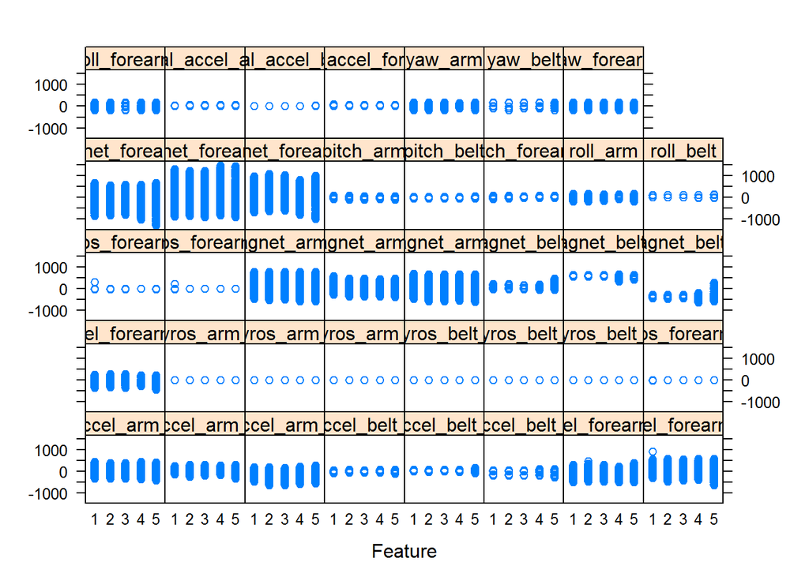

```r
featurePlot(train, outcome, "strip")
```

*plot correlation matrix* A set of good variable are that have low correlation between each other

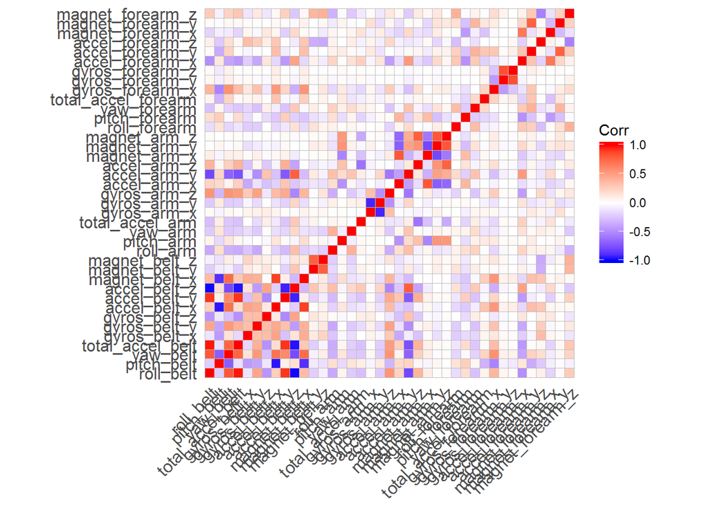

```r
cor <- cor(train)
ggcorrplot(cor)
```

*PCA* apply the *principal coponent analysis* algorithm (PCA) to generate a set of orthognal features. With low correlation.

```r
ppv <- preProcess(train, method = "pca",thresh = 0.8)
train <- predict(ppv,train)
test  <- predict(ppv,test)
dim(train)
```

```
## [1] 19622    11
```

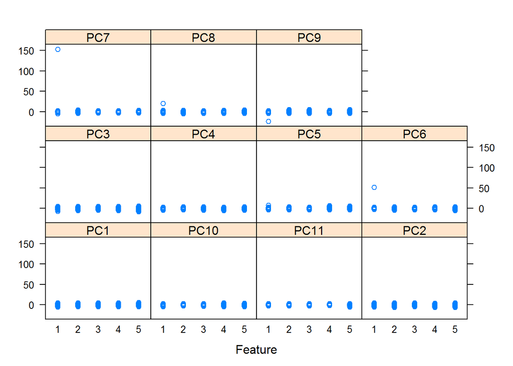

```r
featurePlot(train, outcome, "strip")
```

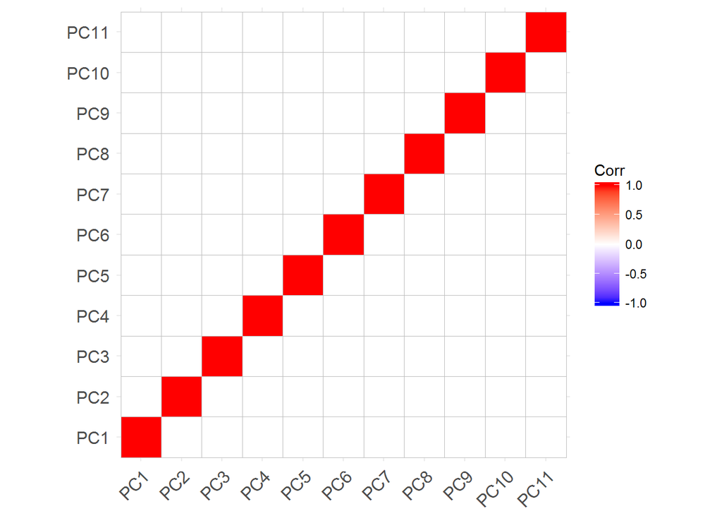

```r
cor <- cor(train)
ggcorrplot(cor)
```

## Model building

Apply 2-fold cross validation

```r
tcontrol <- trainControl(method = "cv",number = 2)
```

Build a model using randomForest algoorithm

```r
train$outcome <- outcome
rfFit <- train(outcome ~ ., data = train,
                 method = "rf",
                 trControl = tcontrol
                 )
```

Predict on test set

```r
dim(test)
```

```
## [1] 20 11
```

```r
pre <- predict(rfFit,test)
pre
```

```
##  [1] 2 1 1 1 1 5 4 2 1 1 2 1 2 1 5 5 1 2 2 2
## Levels: 1 2 3 4 5
```